# Uncertainity of position and momentum for different eigen values of the "coherent state".

Note: This is not part of the project, but a detour.

The aim here would be to plot $\Delta x \Delta p$ as a function of time, for different values of $\alpha$, namely we will change $p_1$ and $q_1$ and observe the changes which are brought about hence forth.

We shall write a function which takes in the parameters $p_1$ and $q_1$ , the minimum and the maximum x-axis values for the graph.

`def deltaxp(p, q, begin, end, finarr) #p1,q1,minimum x-axis val, maximum x-axis val`

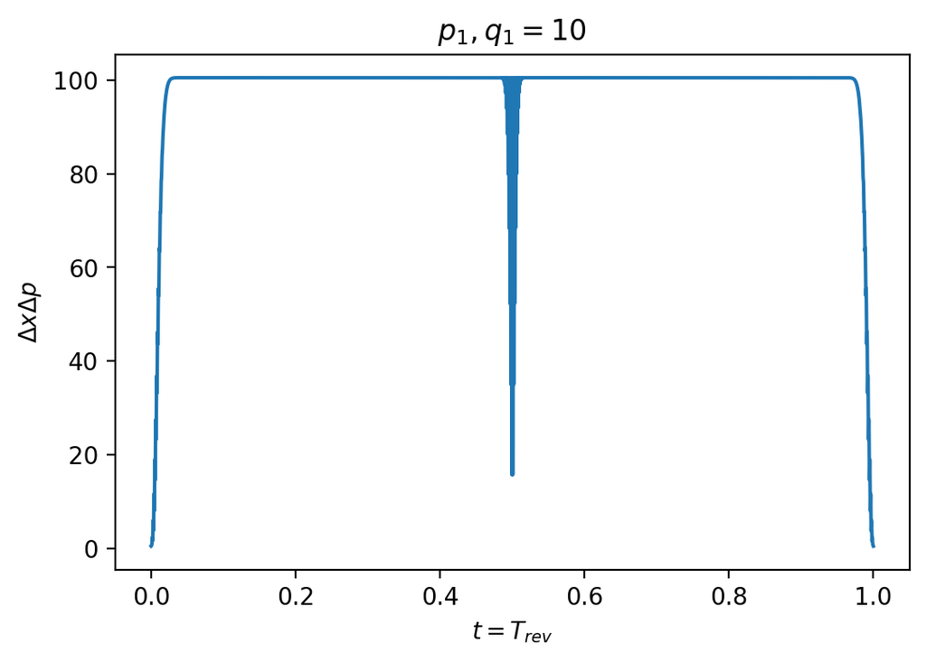

```python
import matplotlib.pyplot as plt
import numpy as np

f = np.pi

deltaxp = []

stepsize = 50000

time = np.linspace(0,1,10000)

def delta_xp(p,q,begin,end,step,finarr):
    for t in np.arange(begin,end,step):
        plus = p**2 + q**2
        minus = p**2 - q**2
        a1 = np.exp(-1 * plus * (1 - np.cos(2 * f * t)))
        a2 = np.exp(-1 * plus * (1 - np.cos(4 * f * t)))
        b1 = np.cos(plus * (np.sin(2 * f * t)))
        c1 = np.sin(plus * (np.sin(2 * f * t)))
        b2 = np.cos((2 * f * t) + (plus * np.sin(4 * f * t)))
        c2 = np.sin((2 * f * t) + (plus * np.sin(4 * f * t)))

        finx = a1 * ((p * b1) + (q * c1))
        finp = a1 * ((p * c1) - (q * b1))

        finx2 = 0.5 * (1 + plus + a2 * (((minus) * b2) + (2 * p * q) * c2))
        finp2 = 0.5 * (1 + plus - a2 * (((minus) * b2) + (2 * p * q) * c2))

        deltax = np.sqrt(finx2 - (finx**2))
        deltap = np.sqrt(finp2 - (finp**2))

        final = deltax * deltap

        finarr.append(final)

delta_xp(10,10,0,1,0.0001,deltaxp)

plt.rcParams["figure.dpi"] = 200

plt.plot(time,deltaxp)
plt.xlabel("$t = T_{rev}$")
plt.ylabel("$\Delta x \Delta p$")
plt.title("$p_1 , q_1 = 10$")
plt.show()
```

We know that the dip in the centre corresponds to the first fractional revival. We shall **zoom into** this area in the graph to understand it better.

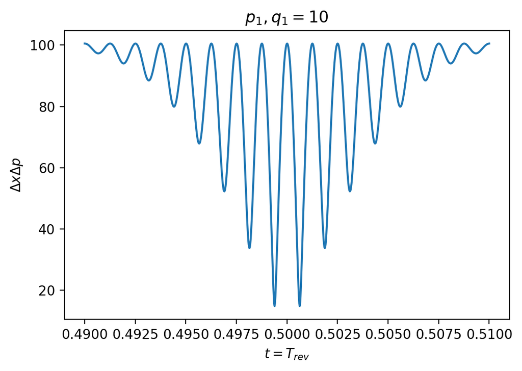

```python
dxp2 = []

time2 = np.linspace(0.49,0.51,1000)

delta_xp(10,10,0.49,0.51,0.00002,dxp2)
dxp2.pop(len(dxp2) - 1)
plt.plot(time2,dxp2)
plt.xlabel("$t = T_{rev}$")
plt.ylabel("$\Delta x \Delta p$")
plt.title("$p_1 , q_1 = 10$")
plt.show()
```

The above graph shows that exactly at the time of the first fractional revival which is $t = \frac{T_{rev}}{2}$ the uncertainity is not minimum. The uncertainity fluctuates wildly here, as a function of time.

When we set $\nu = 1000$ the plot is like this:

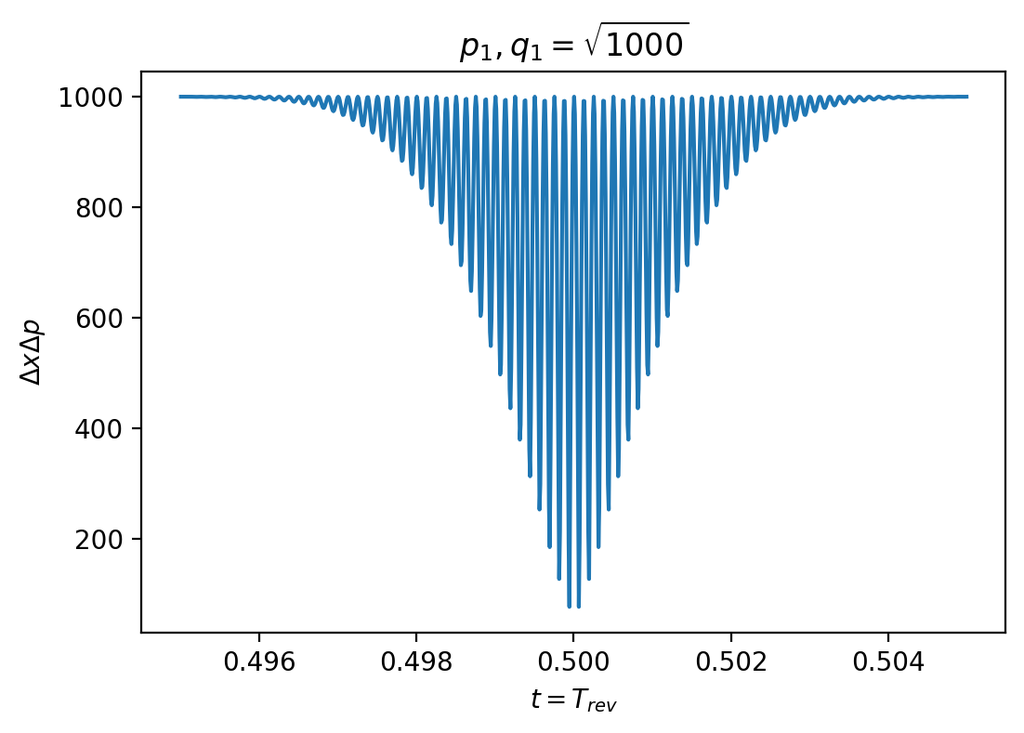

```python
dxp3 = []

time2 = np.linspace(0.495,0.505,1000)

delta_xp(np.sqrt(1000),np.sqrt(1000),0.495,0.505,0.00001,dxp3)
dxp3.pop(len(dxp3) - 1)
plt.plot(time2,dxp3)
plt.xlabel("$t = T_{rev}$")
plt.ylabel("$\Delta x \Delta p$")
plt.title("$p_1 , q_1 = \sqrt{1000}$")
plt.show()
```

This would suggest that at the time of fractional revival for high values of $\nu$, the wave packet slowly moves towards its first fractional revival state of two small gaussians,by "passing" through states where the number of gaussians are large, but their individual "ampltitude" so to speak, is low. (Thus, it does not immediately take the form of two small gaussians.)

I might be wrong here, but as of yet, this is what I think.